# Lab_1 Solutions

Kelly Bodwin

## About the dataset

This dataset contains information about the qualities of certain car models made in 1999 and 2008.

It has 234 rows and 11 variables.

(The plots below are only one option out of many possibilities, of course.)

## Plot 1:

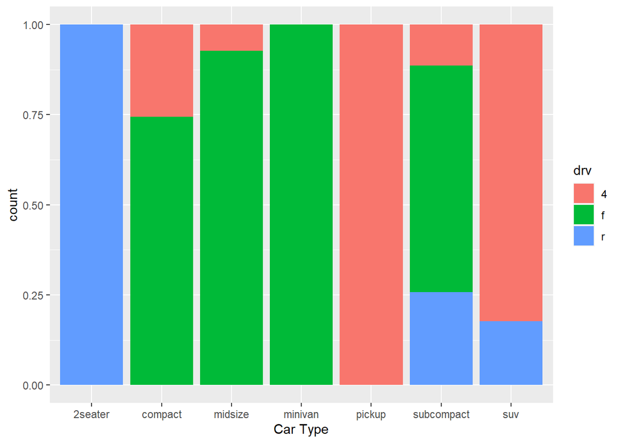

```r
cars %>%
  ggplot(aes(x = class, fill = drv)) +
  geom_bar(position = "fill") +
  xlab("Car Type")
```

This plot shows us the type of drive train (4 wheel drive, front-wheel drive, or rear-wheel drive) for each class of car in this dataset. We can see that pickup trucks are all 4-wheel drive, 2-seaters are all rear-wheel drive, and minivans are all front-wheel drive. Subcompact cars have the most variety in drive train.

## Plot 2:

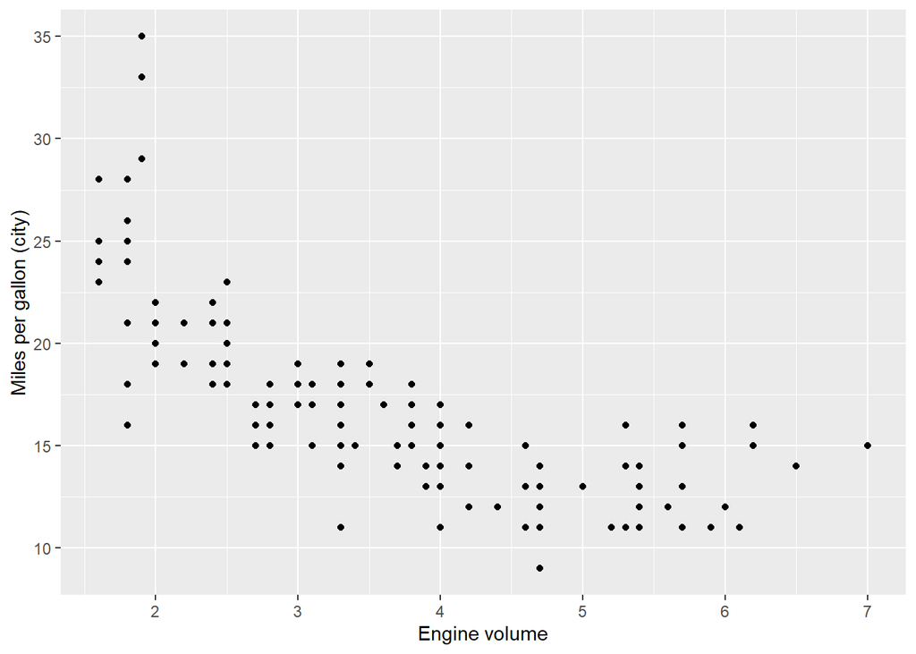

```r
cars %>%
  ggplot(aes(x = displ, y = cty)) +
  geom_point() +
  xlab("Engine volume") +
  ylab("Miles per gallon (city)")
```

This plot shows the relationship between engine volume (“displacement”) and the miles per gallon of the car. We can see that more powerful cars - i.e. those with a larger volume - tend to have a lower fuel efficiency. The relationship is not linear.

## Plot 3:

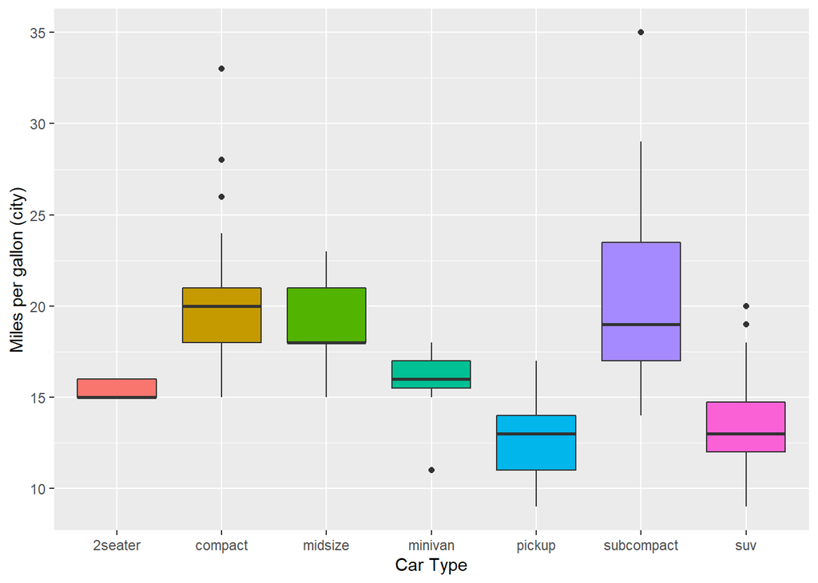

```r
cars %>%
  ggplot(aes(x = class, y = cty, fill = class)) +
  geom_boxplot() +
  xlab("Car Type") +
  ylab("Miles per gallon (city)") +
  theme(legend.position = "none")
```

This plot shows the fuel efficiency (miles per gallon) of each car type. Larger cars like pickups and SUVs get fewer miles per gallon, while smaller cars are more efficient.